# Week05_Monday slides

## Week 05 Monday

Sept 23, 2024

## Announcements

1. A04 due **Wednesday, 9/25/2024**
2. Next A05 deliverable is a draft list of included articles due **10/2/2024**
3. A06 due **Friday, 10/4/2024**

A03 feedback shortly, will prioritize reading your protocols for A05 next.

## Goals

1. Application of rotations: Odometry Estimates
2. Class exercise: Write a function that computes odometry for Romi "explorer."

# What is Odometry?

### Imagine that you're in a dark room. You need to know where you are in the room relative to its X,Y allocentric frame. How would you keep track of this?

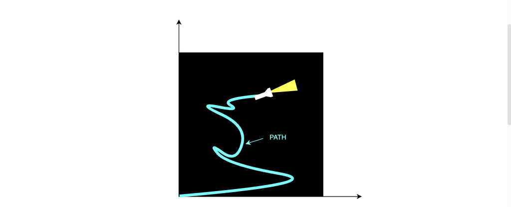

# What is Odometry?

Odometry or dead reckoning for a robot moving on a plane is computing a robot's global position by integrating its global velocity. It consists of these steps, which occur in each "loop" of a program running on the robot (in other words, at every timestep $k$):

1. Compute the body-fixed velocity of the robot $^B\vec{v}$ and the robot's angular velocity $^B\vec{\omega}$
2. Transform these into the allocentric frame by computing $^A\vec{v}$ and $^A\vec{\omega}$
3. Integrate $^A\vec{\omega}$ to find the orientation of the robot in the global (allocentric) frame
4. Using the robot's orientation, transform $^B\vec{v}$ into $^A\vec{v}$ to get the robot's allocentric velocity
5. Integrate $^A\vec{v}$ to get the position of the robot in the allocentric frame.

Note that this list of steps assumes that the robot does not have an allocentric orientation sensor (such as a compass). If it does, you can skip step 3!

## What does Odometry look like on the Romi?

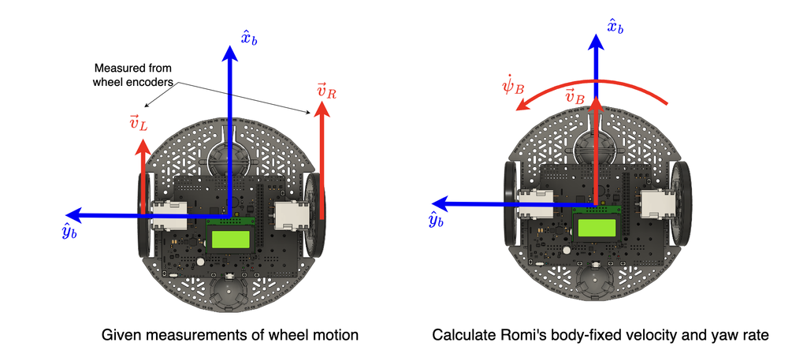

## What does Odometry look like on the Romi?

In order to compute odometry estimates for the Romi, we need to find:

1. $^B\vec{v}_B$
2. $\dot{\psi}$

Based on the wheel velocities $^B\vec{v}_L,^B\vec{v}_R$.

Once we have these, we will be able to perform the steps to get odometry estimates

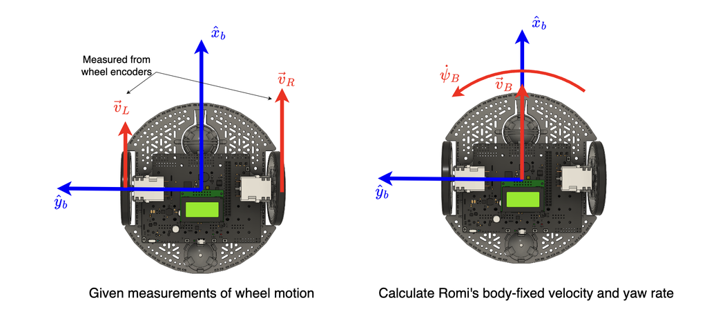

## Key Concept: relative motion on a rigid body:

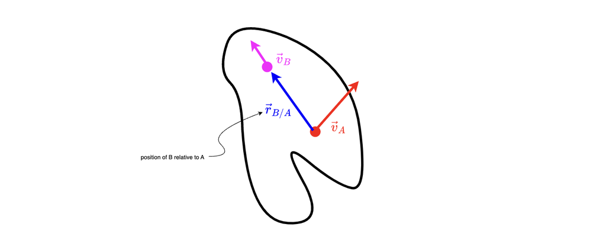

\begin{equation} \vec{v}_B = \vec{v}_A + \vec{\omega}\times \vec{r}_{B/A} \end{equation} where $\vec{\omega}$ represents the rigid body's *angular velocity* vector.

## How do we apply this to the Romi to find what we need?

## How do we apply this to the Romi to find what we need?

### Finding Romi's Yaw Rate

\begin{equation} \begin{aligned} ^B\vec{v}_{L} &= ^B\vec{v}_R + \dot{\psi}\hat{z}_B \times 2r \hat{y}_B \\ v_L\hat{x}_B &= v_R\hat{x}_B - 2r\dot{\psi}\hat{x}_B \end{aligned} \end{equation}

Because each term is multiplied by the same unit vector $\hat{x}_B$, this becomes a scalar equation that we can solve for $\dot{\psi}$.

\begin{equation} \dot{\psi} = \frac{v_R-v_L}{2r} \end{equation}

A unit check confirms that the equation has the correct units (rad/s).

.

.

.

.

## How do we apply this to the Romi to find what we need?

### Finding the velocity of Romi's center

To find $\vec{v}_{B}$, we can simply apply the rigid body formula again, now that we *know* Romi's yaw rate. Using the left wheel as our reference point, we find:

\begin{equation} \vec{v}_B = \vec{v}_L + \vec{\omega}\times\vec{r}_{B/L} \end{equation}

Substituting the position vector and angular velocity specific to the Romi, we find:

\begin{equation} \vec{v}_B = {v}_L\hat{x}_B + \dot{\psi}\hat{z}_B \times -r \hat{y}_B \end{equation}

Notice that $\vec{r}_{B/A}=-r\hat{y}_B$ because to get from the left wheel to the romi's center, you must move in the negative y-direction.

Performing the cross product $\hat{z}_B\times-\hat{y}_B=\hat{x}_B$ using the right-hand rule, and realizing that $\vec{v}_L=v_L\hat{x}_B$ tells us that the result we get for $\vec{v}_B$ will necessarily also be in the $\hat{x}_B$ direction. This means we can solve for the scalar magnitude $v_B$, which, after some algebra, is:

\begin{equation} v_b = \frac{v_L+v_R}{2} \end{equation}

.

.

.

.

## Using $\dot{\psi}$ and $\vec{v}_B$ to complete our odometry estimates

Integrating the Romi's angular velocity $\dot{\psi}$ allows us to estimate the robot's yaw angle $\psi$, which we can use to perform a *rotation* on the Romi's body-fixed velocity $^B\vec{v}_B$ before integrating to get global position estimates $^AX,^AY$. This can be accomplished by performing the rotation from body-fixed to global frames.

\begin{equation} ^A\vec{v}=_B^AR_z(\psi) ^B\vec{v} \end{equation}

Where: $_B^A R_z(\psi)$ in 2D is given by:

\begin{equation} _B^A R(\psi)=\begin{bmatrix} \cos\psi & -\sin\psi \\ \sin\psi & \cos\psi \end{bmatrix} \end{equation}

## Exercise

Modify the Romi controller in the Week05_InClass world. Add a function that computes a new estimate of odometry based on old estimates, along with current wheel velocities. Your function should have the form

```
def doOdometry(Xold,Yold,Yawold,Vl,Vr,timestep):
    #your function should:
    #1. Compute yaw rate based on Vl, Vr, and romi geometry
    #2. Use Euler integration to find Yawnew based on Yawold, yaw rate and timestep
    #3. Compute body-fixed velocity bv based on Vl, Vr, and romi geometry
    #4. Rotate body-fixed velocity to find VX, VY in global frame
    #5. Use Euler integration to find Xnew, Ynew based on Xold, Yold, VX, Vy, timestep

    return Xnew, Ynew, Yawnew #can return more (i.e. yaw rate) if you like
```

Remember, Euler integration allows us to compute a "new" value for some integral $y(k)$ based on an "old" value $y(k-1)$, a velocity $\dot{y}(k-1)$, and a timestep $\Delta t$ by:

\begin{equation} y(k) = y(k-1) + \dot{y}(k-1)\Delta t \end{equation}

Which can be written without using indices and without storing our estimates in a "vector" by simply writing:

\begin{equation} y_{new} = y_{old} + \dot{y}_{old}\Delta t \end{equation}

.

.

.

.